# Part II - (Olympic Winter Medals Presenetation)

## by (Ebtisam Alshehri)

## Investigation Overview

> This presentation aims to demonstrate some of the main findings I discovered during exploration. Prior to exploration, I wanted to discover the gender distribution, the youngest Olympic athletes' ages, and the relationship between the top 5 countries and medal type.

## Dataset Overview

> The dataset is made up of 2865 records and 9 columns named (Year, Sport, Event, Country, Gender, Medal, Medal Rank, Name of Athlete or Team, and Age) Because our dataset contains many categorical variables, we will investigate the relationship for some of them

## (Gender Distribution)

> The following visualization illustrates the gender distribution; as we concluded, more medals are awarded to men. Additionally, an interesting fact we have discovered is that there are medals awarded to both genders in mixed.

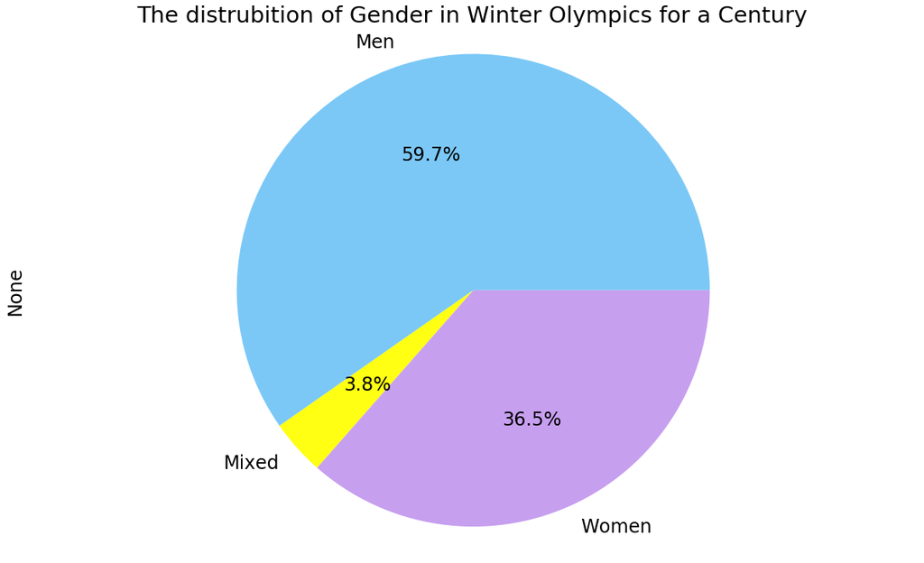

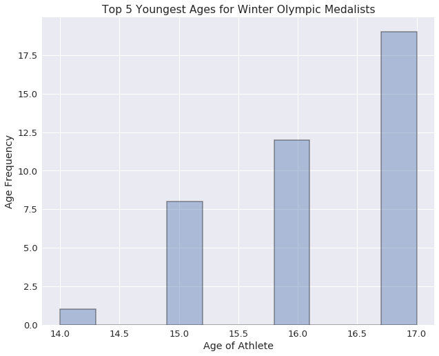

## (Top 5 Countries and Their Most Common medals)

> When it comes to European countries, gold medals are most common, except for Austria (bronze medals are most common there).

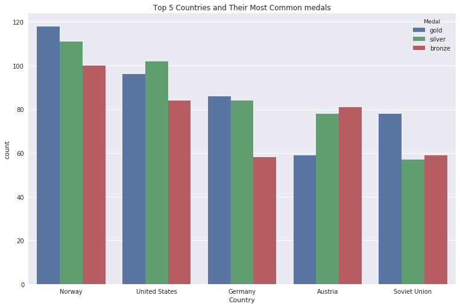